# RS-ecommerce-Proj

# Using different algorithms

```python
benchmark=[]
#iterate over the below algos
for algorithm in [SVD(), KNNBaseline(),KNNWithMeans(), BaselineOnly()]:
    #perform cross validartion
    results=cross_validate(algorithm,data,measures=['RMSE'],cv=3,verbose=False)
    tmp=pd.DataFrame.from_dict(results).mean(axis=0)
    tmp=tmp.append(pd.Series([str(algorithm).split(' ')[0].split('.')[-1]],index=['Algorithm']))
    benchmark.append(tmp)

pd.DataFrame(benchmark).set_index('Algorithm').sort_values('test_rmse')
```

```
Estimating biases using als...
Computing the msd similarity matrix...
Done computing similarity matrix.
Estimating biases using als...
Computing the msd similarity matrix...
Done computing similarity matrix.
Estimating biases using als...
Computing the msd similarity matrix...
Done computing similarity matrix.
Computing the msd similarity matrix...
Done computing similarity matrix.
Computing the msd similarity matrix...
Done computing similarity matrix.
Computing the msd similarity matrix...
Done computing similarity matrix.
Estimating biases using als...
Estimating biases using als...
Estimating biases using als...
```

| Algorithm | test_rmse | fit_time | test_time |
| --- | --- | --- | --- |
| BaselineOnly | 0.979150 | 0.374958 | 0.230638 |
| SVD | 0.983123 | 4.823208 | 0.290069 |
| KNNBaseline | 1.040478 | 0.466759 | 0.772360 |
| KNNWithMeans | 1.063952 | 0.168496 | 0.714408 |

From the above, we can see that BaselineOnly algo gives us the best RMSE of 0.979(lowest), therefore we will train and predict with BaselineOnly and use AlternateLeastSquares(ALS)

```python
#Using the AlternateLeastSquares(ALS)
bsl_options={'method':'als',
             'n_epochs': 5,
             'reg_u': 12,
             'reg_i': 5
            }
algo=BaselineOnly(bsl_options=bsl_options)
cross_validate(algo, data, measures=['RMSE'], cv=3, verbose=False)
```

```
Estimating biases using als...
Estimating biases using als...
Estimating biases using als...
```

```
{'test_rmse': array([0.97171654, 0.97572498, 0.98491438]),
 'fit_time': (0.17800617218017578, 0.21052002906799316, 0.21723604202270508),
 'test_time': (0.2330172061920166, 0.22957897186279297, 0.21122503280639648)}
```

```python
#using ALS , we are able to reduce the RMSE a bit and getting the best results
```

```python
trainset, testset = train_test_split(data, test_size=0.30)
algo=BaselineOnly(bsl_options=bsl_options)
algo.fit(trainset)
predictions =algo.test(testset)
# Compute and print Root Mean Squared Error
accuracy.rmse(predictions)
```

```
Estimating biases using als...
RMSE: 0.9793
```

```
0.979308528478391
```

```python
def get_Iu(uid):
    """ return the number of items rated by given user
    args:
      uid: the id of the user
    returns:
      the number of items rated by the user
    """
    try:
        return len(trainset.ur[trainset.to_inner_uid(uid)])
    except ValueError: # user was not part of the trainset
        return 0

def get_Ui(iid):
    """ return number of users that have rated given item
    args:
      iid: the raw id of the item
    returns:
      the number of users that have rated the item.
    """
    try:
        return len(trainset.ir[trainset.to_inner_iid(iid)])
    except ValueError:
        return 0

df = pd.DataFrame(predictions, columns=['uid', 'iid', 'rui', 'est', 'details'])
df['Iu'] = df.uid.apply(get_Iu)
df['Ui'] = df.iid.apply(get_Ui)
df['err'] = abs(df.est - df.rui)
```

```python
df.head()
```

[output not shown]

```python
best_predictions = df.sort_values(by='err')[:10]
worst_predictions = df.sort_values(by='err')[-10:]
```

```python
best_predictions
```

[output not shown]

```python
worst_predictions
```

[output not shown]

# Popularity Recommender model

```python
#Count of user_id for each unique product as recommendation score
data_grouped=filterdf.groupby('productId').agg({'userId':'count'}).reset_index()
data_grouped.head(5)
```

|  | productId | userId |
| --- | --- | --- |
| 0 | 0594481813 | 1 |
| 1 | 0970407998 | 2 |
| 2 | 0972683275 | 3 |
| 3 | 1400501466 | 5 |
| 4 | 1400501520 | 1 |

```python
data_grouped.rename(columns={'userId':'score'},inplace=True)
data_grouped.head(5)
```

|  | productId | score |
| --- | --- | --- |
| 0 | 0594481813 | 1 |
| 1 | 0970407998 | 2 |
| 2 | 0972683275 | 3 |
| 3 | 1400501466 | 5 |
| 4 | 1400501520 | 1 |

```python
data_sort=data_grouped.sort_values(['score','productId'],ascending=[0,1])
```

```python
data_sort['Rank'] = data_sort['score'].rank(ascending=0, method='first')
```

```python
#Get the top 5 recommendations for user
popularity_recommendations = data_sort.head(5)
popularity_recommendations
```

|  | productId | score | Rank |
| --- | --- | --- | --- |
| 38146 | B0088CJT4U | 204 | 1.0 |
| 24262 | B003ES5ZUU | 177 | 2.0 |
| 10820 | B000N99BBC | 163 | 3.0 |
| 37407 | B007WTAJTO | 156 | 4.0 |
| 37765 | B00829TIEK | 146 | 5.0 |

```python
#make the popularity based recommender model
#Since this is a popularity-based recommender model, recommendations remain the same for all users
#We predict the products based on the popularity. It is not personalized to particular user
def popularity_recommend_model(user_id):
    user_recommendations=popularity_recommendations
    user_recommendations['userId']=user_id
    cols=user_recommendations.columns.tolist()
    cols=cols[-1:]+cols[:-1]
    user_recommendations=user_recommendations[cols]
    return user_recommendations
```

```python
#recommend top 5 new products to user 'ARBKYIVNYWK3C'
userId='ARBKYIVNYWK3C'
popularity_recommend_model(userId)
```

|  | userId | productId | score | Rank |
| --- | --- | --- | --- | --- |
| 38146 | ARBKYIVNYWK3C | B0088CJT4U | 204 | 1.0 |
| 24262 | ARBKYIVNYWK3C | B003ES5ZUU | 177 | 2.0 |
| 10820 | ARBKYIVNYWK3C | B000N99BBC | 163 | 3.0 |
| 37407 | ARBKYIVNYWK3C | B007WTAJTO | 156 | 4.0 |
| 37765 | ARBKYIVNYWK3C | B00829TIEK | 146 | 5.0 |

```python
#here recommend the top products for user "ARBKYIVNYWK3C" based on the star rating/most popular items
filterdf[(filterdf['userId']=='ARBKYIVNYWK3C')]
```

|  | userId | productId | Rating | timestamp |
| --- | --- | --- | --- | --- |
| 67449 | ARBKYIVNYWK3C | B00004Z5PY | 5.0 | 1253923200 |
| 77424 | ARBKYIVNYWK3C | B00005108H | 5.0 | 1265587200 |
| 137786 | ARBKYIVNYWK3C | B0000642RX | 4.0 | 1267315200 |
| 153983 | ARBKYIVNYWK3C | B000067RT6 | 5.0 | 1260835200 |
| 155895 | ARBKYIVNYWK3C | B000067SG2 | 5.0 | 1253923200 |
| ... | ... | ... | ... | ... |
| 7814464 | ARBKYIVNYWK3C | B00JO6UGFU | 5.0 | 1403308800 |
| 7814944 | ARBKYIVNYWK3C | B00JPELAB0 | 4.0 | 1401753600 |
| 7816566 | ARBKYIVNYWK3C | B00JVOTUGQ | 5.0 | 1400025600 |
| 7819417 | ARBKYIVNYWK3C | B00K6B7KJM | 4.0 | 1404691200 |
| 7823031 | ARBKYIVNYWK3C | B00KMRGB7C | 4.0 | 1405296000 |

296 rows × 4 columns

# Collaborative Filtering model

In Collaborative Filtering model ,For each user, recommender systems recommend items based on how similar users liked the item

First we will use KNN model here as KNN is a perfect go-to model and also a very good baseline for recommender system development. KNN is a non-parametric, lazy learning method. It uses a database in which the data points are separated into several clusters to make inference for new samples.

# 1. Using KNNWithMeans model

```python
def CF_algo(trainset,testset,k,similarity_matrix,user_based):
    algo=KNNWithMeans(k,sim_options={'name':similarity_matrix,'user_based':user_based})
    algo.fit(trainset)
    test_pred=algo.test(testset)
    return test_pred
```

# 1.a: Pearson similarity

```python
#User based CF
test_pred=CF_algo(trainset,testset,40,'pearson',True)
```

```
Computing the pearson similarity matrix...
Done computing similarity matrix.
```

```python
print("pearson similarity for user based CF is ", accuracy.rmse(test_pred))
```

```
RMSE: 1.0466
pearson similarity for user based CF is  1.0465818190715799
```

```python
#Item based CF
test_pred=CF_algo(trainset,testset,40,'pearson',False)
```

```
Computing the pearson similarity matrix...
Done computing similarity matrix.
```

```python
print("pearson similarity for Item based CF is ", accuracy.rmse(test_pred))
```

```
RMSE: 1.1337
pearson similarity for Item based CF is  1.1336686658689947
```

# 1.b): Cosine similarity

```python
#User based CF
test_pred=CF_algo(trainset,testset,40,'cosine',True)
```

```
Computing the cosine similarity matrix...
Done computing similarity matrix.
```

```python
print("Cosine similarity for user based CF is ", accuracy.rmse(test_pred))
```

```
RMSE: 1.0566
Cosine similarity for user based CF is  1.0566020706459396
```

```python
test_pred=CF_algo(trainset,testset,40,'cosine',False)
```

```
Computing the cosine similarity matrix...
Done computing similarity matrix.
```

```python
print("Cosine similarity for item based CF is ", accuracy.rmse(test_pred))
```

```
RMSE: 1.1256
Cosine similarity for item based CF is  1.1255953245427903
```

```python
test_pred_df = pd.DataFrame(test_pred)
```

```python
test_pred_df.head()
```

|  | uid | iid | r_ui | est | details |
| --- | --- | --- | --- | --- | --- |
| 0 | A2L42QEWR77PKZ | B005LJQM3Y | 5.0 | 5.000000 | {'actual_k': 0, 'was_impossible': False} |
| 1 | A2OWR5G2OAQF7C | B004P15HD0 | 5.0 | 4.261533 | {'was_impossible': True, 'reason': 'User and/o... |
| 2 | A3O4OIBCML0683 | B004Z0S6RU | 5.0 | 5.000000 | {'actual_k': 2, 'was_impossible': False} |
| 3 | A2JAEZ0FMAMJVW | B0030LGY38 | 3.0 | 4.261533 | {'was_impossible': True, 'reason': 'User and/o... |
| 4 | A6FIAB28IS79 | B000FCSXBQ | 4.0 | 4.261533 | {'was_impossible': True, 'reason': 'User and/o... |

# Top 5 user resommendations

```python
testset_new = trainset.build_anti_testset()
```

```python
len(testset_new)
```

```
54886549
```

```python
testset_new[0:5]
```

```
[('AKT8TGIT6VVZ5', 'B00DR0PDNE', 4.261532524935979),
 ('AKT8TGIT6VVZ5', 'B00104XCVO', 4.261532524935979),
 ('AKT8TGIT6VVZ5', 'B00077KMXG', 4.261532524935979),
 ('AKT8TGIT6VVZ5', 'B00005T3WF', 4.261532524935979),
 ('AKT8TGIT6VVZ5', 'B008ULPE70', 4.261532524935979)]
```

# user-user collaborative filtering is ‘K nearest neighbours with means

```python
#Using pearson  similarity  for user based CF
algo = KNNWithMeans(40,sim_options={'name':'pearson','user_based':True})
algo.fit(trainset)
#Processing will take time if we select the rows, hence selecting 100,000 rows
predictions = algo.test(testset_new[0:100000])
```

```
Computing the pearson similarity matrix...
Done computing similarity matrix.
```

```python
predictions[0:5]
```

```
[Prediction(uid='AKT8TGIT6VVZ5', iid='B00DR0PDNE', r_ui=4.261532524935979, est=4.840579710144928, details={'actual_k': 0, 'was_impossible': False}),
 Prediction(uid='AKT8TGIT6VVZ5', iid='B00104XCVO', r_ui=4.261532524935979, est=4.840579710144928, details={'actual_k': 0, 'was_impossible': False}),
 Prediction(uid='AKT8TGIT6VVZ5', iid='B00077KMXG', r_ui=4.261532524935979, est=4.840579710144928, details={'actual_k': 0, 'was_impossible': False}),
 Prediction(uid='AKT8TGIT6VVZ5', iid='B00005T3WF', r_ui=4.261532524935979, est=4.840579710144928, details={'actual_k': 0, 'was_impossible': False}),
 Prediction(uid='AKT8TGIT6VVZ5', iid='B008ULPE70', r_ui=4.261532524935979, est=4.840579710144928, details={'actual_k': 0, 'was_impossible': False})]
```

```python
predictions_df = pd.DataFrame([[x.uid,x.iid,x.est] for x in predictions])
```

```python
#Add column names
predictions_df.columns=['userID','productId','est_rating']
```

```python
predictions_df.head()
```

|  | userID | productId | est_rating |
| --- | --- | --- | --- |
| 0 | AKT8TGIT6VVZ5 | B00DR0PDNE | 4.84058 |
| 1 | AKT8TGIT6VVZ5 | B00104XCVO | 4.84058 |
| 2 | AKT8TGIT6VVZ5 | B00077KMXG | 4.84058 |
| 3 | AKT8TGIT6VVZ5 | B00005T3WF | 4.84058 |
| 4 | AKT8TGIT6VVZ5 | B008ULPE70 | 4.84058 |

```python
predictions_df.sort_values(by=['userID','est_rating'],ascending=False,inplace=True)
```

```python
#TOP 5 recommendation
predictions_df.head(5)
```

|  | userID | productId | est_rating |
| --- | --- | --- | --- |
| 205 | AKT8TGIT6VVZ5 | B0001EKGG8 | 5.0 |
| 417 | AKT8TGIT6VVZ5 | B00DUN2PBQ | 5.0 |
| 1587 | AKT8TGIT6VVZ5 | B00BT7RAPG | 5.0 |
| 2032 | AKT8TGIT6VVZ5 | B0030MITDK | 5.0 |
| 2167 | AKT8TGIT6VVZ5 | B007BJHETS | 5.0 |

```python
#Above are the top 5 recommended products based on the highest rating for each user
```

```python
predictions_df['userID'].unique().shape[0]  #Unique users
```

```
3
```

# Recommend top 5 products to user

```python
top_5_products=predictions_df.groupby('userID').head(5).reset_index(drop=True)
```

```python
top_5_products
#each user receives personalized product recommendations based on how they rated the products they have purchased/used earlier.
```

|  | userID | productId | est_rating |
| --- | --- | --- | --- |
| 0 | AKT8TGIT6VVZ5 | B0001EKGG8 | 5.000000 |
| 1 | AKT8TGIT6VVZ5 | B00DUN2PBQ | 5.000000 |
| 2 | AKT8TGIT6VVZ5 | B00BT7RAPG | 5.000000 |
| 3 | AKT8TGIT6VVZ5 | B0030MITDK | 5.000000 |
| 4 | AKT8TGIT6VVZ5 | B007BJHETS | 5.000000 |
| 5 | A3SOJO7Z7R9WIA | B000VDF5RO | 4.121882 |
| 6 | A3SOJO7Z7R9WIA | B00006I5J7 | 4.121882 |
| 7 | A3SOJO7Z7R9WIA | B0094AS7VG | 4.121882 |
| 8 | A3SOJO7Z7R9WIA | B000FU774C | 4.121882 |
| 9 | A3SOJO7Z7R9WIA | B00D9MCVOY | 4.121882 |
| 10 | A3OZA8HNJM26DC | B003MTTJOY | 5.000000 |
| 11 | A3OZA8HNJM26DC | B00DIFIM36 | 5.000000 |
| 12 | A3OZA8HNJM26DC | B00008VSL4 | 5.000000 |
| 13 | A3OZA8HNJM26DC | B006JTUM72 | 5.000000 |
| 14 | A3OZA8HNJM26DC | B007JOO4YS | 4.385491 |

# Tweak parameters on KNN using GridSearchCV

Surprise provides a GridSearchCV class analogous to GridSearchCV. With a dict of all parameters, GridSearchCV tries all the combinations of parameters and reports the best parameters for any accuracy measure

```python
from surprise.model_selection import GridSearchCV
```

```python
data = Dataset.load_from_df(filterdf.iloc[:10000,:][['userId', 'productId', 'Rating']], reader)
```

```python
param_grid={'k':[15,20,25,30]}
knnmeans_gs=GridSearchCV(KNNWithMeans, param_grid, measures=['rmse', 'mae'], cv=5, n_jobs=5,refit=True)
knnmeans_gs.fit(data)
```

```
Computing the msd similarity matrix...
Done computing similarity matrix.
```

```python
x = [15, 20, 25, 30]
y1 = knnmeans_gs.cv_results['mean_test_rmse']
y2 = knnmeans_gs.cv_results['mean_test_mae']
```

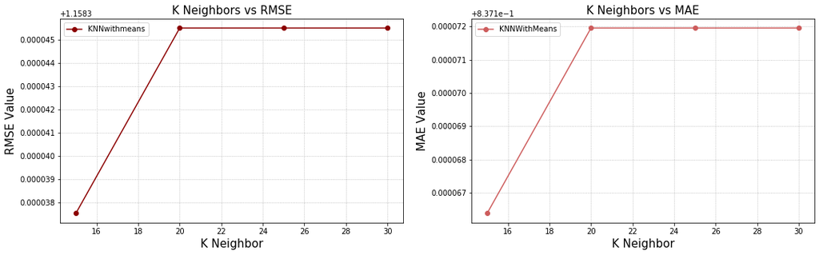

```python
plt.figure(figsize=(18,5))

plt.subplot(1,2,1)
plt.title('K Neighbors vs RMSE', loc='center', fontsize=15)
plt.plot(x,y1,label="KNNwithmeans",color='darkred',marker='o')
plt.xlabel('K Neighbor', fontsize=15)
plt.ylabel('RMSE Value', fontsize=15)
plt.legend()
plt.grid(ls='dotted')

plt.subplot(1, 2, 2)
plt.title('K Neighbors vs MAE', loc='center', fontsize=15)
plt.plot(x, y2, label='KNNWithMeans', color='indianred', marker='o')
plt.xlabel('K Neighbor', fontsize=15)
plt.ylabel('MAE Value', fontsize=15)
plt.legend()
plt.grid(ls='dotted')

plt.show()
```

```python
knnmeans_gs.best_score
```

```
{'rmse': 1.1583375328382972, 'mae': 0.8371663781197052}
```

```python
# get best parameters
knnmeans_gs.best_params
```

```
{'rmse': {'k': 15}, 'mae': {'k': 15}}
```

```python
knn_test_pred = knnmeans_gs.test(testset)
```

```python
accuracy.rmse(knn_test_pred)
```

```
RMSE: 1.0151
```

```
1.0150918334711476
```

```python
#RMSE after gridsearchCV
#RMSE coming on the predicted test data using KNNMeans alogorithm is 1.0151 which is quite good
```

# Model based Collaborative Filtering

# SVD Based Recommendation

```python
from surprise import SVD
from surprise import accuracy
```

```python
svd_model = SVD(n_factors=40,biased=False) # Centered approach
```

```python
svd_model.fit(trainset)
```

```
<surprise.prediction_algorithms.matrix_factorization.SVD at 0x3f1823050>
```

```python
svd_test_pred = svd_model.test(testset)
```

```python
svd_test_pred_df = pd.DataFrame([[x.uid,x.iid,x.est] for x in svd_test_pred])
```

```python
svd_test_pred_df.columns=['userID','productID','est_ratings']
```

```python
svd_test_pred_df.head()
```

|  | userID | productID | est_ratings |
| --- | --- | --- | --- |
| 0 | A2L42QEWR77PKZ | B005LJQM3Y | 1.669516 |
| 1 | A2OWR5G2OAQF7C | B004P15HD0 | 4.261533 |
| 2 | A3O4OIBCML0683 | B004Z0S6RU | 1.694498 |
| 3 | A2JAEZ0FMAMJVW | B0030LGY38 | 4.261533 |
| 4 | A6FIAB28IS79 | B000FCSXBQ | 4.261533 |

```python
svd_test_pred_df.sort_values(by=['userID','est_ratings'],ascending=False,inplace=True)
```

```python
#unique users
svd_test_pred_df['userID'].unique().shape[0]
```

```
1466
```

```python
#top records for user based CF
svd_top_recos = svd_test_pred_df.groupby('userID').head(5).reset_index(drop=True)
```

```python
svd_top_recos.head(10)
```

|  | userID | productID | est_ratings |
| --- | --- | --- | --- |
| 0 | AZOK5STV85FBJ | B00JG5VV9O | 4.261533 |
| 1 | AZOK5STV85FBJ | B00A85ANCW | 4.261533 |
| 2 | AZOK5STV85FBJ | B000L1AUH6 | 4.261533 |
| 3 | AZOK5STV85FBJ | B000UGT5GO | 4.261533 |
| 4 | AZOK5STV85FBJ | B0007WRQ4Y | 4.261533 |
| 5 | AZNUHQSHZHSUE | B0002ZG62E | 4.261533 |
| 6 | AZNUHQSHZHSUE | B000FJEYZI | 4.261533 |
| 7 | AZNUHQSHZHSUE | B001DFZ5J2 | 4.261533 |
| 8 | AZNUHQSHZHSUE | B001L4QFM6 | 4.261533 |
| 9 | AZNUHQSHZHSUE | B0013HH1HY | 4.261533 |

```python
accuracy.rmse(svd_test_pred)
```

```
RMSE: 2.0025
```

```
2.002479735172684
```

```python
#RMSE is coming 2.0025 with the SVD model let's see if we can further fine tune this model to improve on the accuracy and test data prediction
```